# Pythonにおける関数とクラス

関数の定義と実行

```python
import numpy as np

# function
def my_func(a, b):
    return a + b

a = 1
b = 2
print(my_func(a, b))

a = np.random.rand(2)
b = np.random.rand(2)
print(my_func(a, b))
```

```
3
[0.92123581 1.0789616 ]
```

クラスの定義と実行

```python
class my_class():
    def __init__(self, a, b):
        self.a = a
        self.b = b

    def add(self):
        return self.a + self.b

    def sub(self, c):
        return self.a - c

cls = my_class(1, 2)
print(cls.add())
print(cls.sub(5))
```

```
3
-4
```

# Matplotlibによるプロット

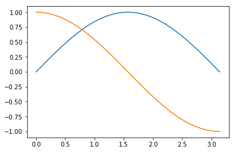

```python
# plotting
import matplotlib.pyplot as plt
%matplotlib inline

t = np.linspace(0, np.pi, 100)
sint = np.sin(t)
cost = np.cos(t)

plt.figure()
plt.plot(t, sint)
plt.plot(t, cost)
```

`plt.subplot`で複数の画像を並べることもできます．

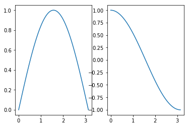

```python
# subplotting
plt.figure()
plt.subplot(1, 2, 1)
plt.plot(t, sint)
plt.subplot(1, 2, 2)
plt.plot(t, cost)
```

散布図は`plt.scatter`で描画できます．

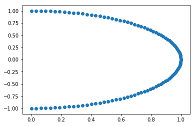

```python
# scatter plotting
plt.figure()
plt.scatter(sint, cost)
```

# 画像，映像の読み込みと表示

ここでは，scikit-image (`skimage`)とscikit-video (`skvideo`) を用いて画像，映像を読み込みましょう．読み込んだ結果は`plt.imshow`で表示できます

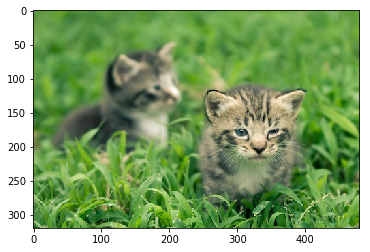

```python
# loading image
from skimage.io import imread
img = imread('data/cat.jpg')
plt.imshow(img)
```

Scikit-videoによる映像の読み込みと表示

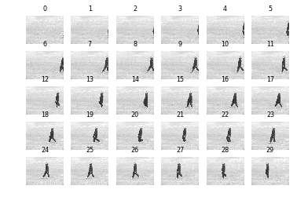

```python
# loading image
# !pip install scikit-video
from skvideo.io import vread
video = vread('data/person15_walking_d1_uncomp.avi')

for t in range(30):
    plt.subplot(5, 6, t + 1)
    plt.imshow(video[t * 2])
    plt.axis('off')
    plt.title(t, fontsize=8)
```

# 課題

1. 映像と自然数`t`を入力とし，`1, t, 2t, ...`フレーム目の画像を並べて表示する関数を作成しましょう．
2. （発展課題）画像パスと，その画像に含まれる物体IDが以下のように `files.txt`にまとめられています．これに対して，以下のプログラムを作成しましょう．
   1. `data/files.txt`の内容を`numpy.array`形式で読み込む
   2. 指定された特定の物体IDに対して，そのIDを持つ画像を全て読み込み，`plt.subplot`で列挙表示する
   3. `data/files.txt`に含まれる画像を全て読み込み，全てを指定されたサイズ（幅`W`, 高さ`H`）にリサイズし，`W_H`という新しいディレクトリ下に保存する
   4. C.でリサイズされた画像について，物体IDごとに平均画像を作成し，表示する

```python
%%bash

cat data/file.txt
```

```
data/caltech101_part/image_0001.jpg 0
data/caltech101_part/image_0002.jpg 0
data/caltech101_part/image_0003.jpg 0
data/caltech101_part/image_0004.jpg 0
data/caltech101_part/image_0005.jpg 0
data/caltech101_part/image_0006.jpg 0
data/caltech101_part/image_0007.jpg 0
data/caltech101_part/image_0008.jpg 0
data/caltech101_part/image_0009.jpg 0
data/caltech101_part/image_0010.jpg 0
data/caltech101_part/image_0011.jpg 1
data/caltech101_part/image_0012.jpg 1
data/caltech101_part/image_0013.jpg 1
data/caltech101_part/image_0014.jpg 1
data/caltech101_part/image_0015.jpg 1
data/caltech101_part/image_0016.jpg 1
data/caltech101_part/image_0017.jpg 1
data/caltech101_part/image_0018.jpg 1
data/caltech101_part/image_0019.jpg 1
data/caltech101_part/image_0020.jpg 1
data/caltech101_part/image_0021.jpg 1
data/caltech101_part/image_0022.jpg 1
data/caltech101_part/image_0023.jpg 1
data/caltech101_part/image_0024.jpg 1
data/caltech101_part/image_0025.jpg 1
data/caltech101_part/image_0026.jpg 2
data/caltech101_part/image_0027.jpg 2
data/caltech101_part/image_0028.jpg 2
data/caltech101_part/image_0029.jpg 2
data/caltech101_part/image_0030.jpg 2
```